# German Credit Data EDA

Notebook for Elementary Data Analysis on the German Credit dataset. This notebook will do statistical exploration, generate various visualizations, and make some suggestions if a model were to be created to predict the target variable, Risk.

There are 11 columns (1 id column, 9 explanatory variables, 1 response variable) with 1000 observations (rows). Each observation is representative of a person who takes a credit by a bank and given a “good” or a “bad” credit risk assessment. The original dataset by Pro. Hofmann included 20 variables, but was in a complicated format. The dataset used in this analysis has been cleansed and the number of columns reduced.

Dataset downloaded from the Kaggle [here](https://www.kaggle.com/kabure/german-credit-data-with-risk).

# Setup

```r
# Load libraries

library(ggplot2)
library(psych, warn.conflicts = FALSE)

# Load data
credit <- read.csv("../data/german_credit_data.csv", header=TRUE, sep=",")

# Checking the first few rows of the dataset
head(credit)
```

|  | X | Age | Sex | Job | Housing | Saving.accounts | Checking.account | Credit.amount | Duration | Purpose | Risk |
| --- | --- | --- | --- | --- | --- | --- | --- | --- | --- | --- | --- |
| 1 | 0 | 67 | male | 2 | own | NA | little | 1169 | 6 | radio/TV | good |
| 2 | 1 | 22 | female | 2 | own | little | moderate | 5951 | 48 | radio/TV | bad |
| 3 | 2 | 49 | male | 1 | own | little | NA | 2096 | 12 | education | good |
| 4 | 3 | 45 | male | 2 | free | little | little | 7882 | 42 | furniture/equipment | good |
| 5 | 4 | 53 | male | 2 | free | little | little | 4870 | 24 | car | bad |
| 6 | 5 | 35 | male | 1 | free | NA | NA | 9055 | 36 | education | good |

Using `head()` to look at the first few rows of the German Credit dataset, we can see that there are nine explanatory variables and one response variable (“Risk”). Of the nine explanatory variables, 4 are int-based and five are chr-based. However, to proceed to the modeling stage, the categorical variables need to either be changed to a numerical scale or one-hot encoded.

# First look into the data

Using `describe()` from the `psych` library, let’s take a look at the summary statistics of the data.

```r
describe(credit)
```

|  | vars | n | mean | sd | median | trimmed | mad | min | max | range | skew | kurtosis | se |
| --- | --- | --- | --- | --- | --- | --- | --- | --- | --- | --- | --- | --- | --- |
| X | 1 | 1000 | 499.50 | 288.82 | 499.5 | 499.50 | 370.65 | 0 | 999 | 999 | 0.00 | -1.20 | 9.13 |
| Age | 2 | 1000 | 35.55 | 11.38 | 33.0 | 34.17 | 10.38 | 19 | 75 | 56 | 1.02 | 0.58 | 0.36 |
| Sex* | 3 | 1000 | 1.69 | 0.46 | 2.0 | 1.74 | 0.00 | 1 | 2 | 1 | -0.82 | -1.33 | 0.01 |
| Job | 4 | 1000 | 1.90 | 0.65 | 2.0 | 1.91 | 0.00 | 0 | 3 | 3 | -0.37 | 0.49 | 0.02 |
| Housing* | 5 | 1000 | 2.07 | 0.53 | 2.0 | 2.09 | 0.00 | 1 | 3 | 2 | 0.07 | 0.46 | 0.02 |
| Saving.accounts* | 6 | 817 | 1.46 | 0.87 | 1.0 | 1.25 | 0.00 | 1 | 4 | 3 | 1.83 | 2.15 | 0.03 |
| Checking.account* | 7 | 606 | 1.65 | 0.66 | 2.0 | 1.57 | 1.48 | 1 | 3 | 2 | 0.52 | -0.73 | 0.03 |
| Credit.amount | 8 | 1000 | 3271.26 | 2822.74 | 2319.5 | 2754.57 | 1627.15 | 250 | 18424 | 18174 | 1.94 | 4.25 | 89.26 |
| Duration | 9 | 1000 | 20.90 | 12.06 | 18.0 | 19.47 | 8.90 | 4 | 72 | 68 | 1.09 | 0.90 | 0.38 |
| Purpose* | 10 | 1000 | 3.88 | 1.98 | 4.0 | 3.91 | 2.97 | 1 | 8 | 7 | -0.01 | -1.54 | 0.06 |

[output cut: 1 more lines]

Noteworthy points:

- `Sex` and `Risk` are binary variable columns. Taking a look at how each of the the classes in those variables impact the rest of the distributions will be a good place to start EDA.
- The average `Age` of the dataset is 35.55, with a minimum age of 19 and a maximum age of 75.
- The `Job` variable, while the values are int-based, is actually a categorical variable. The numerical values have the corresponding meanings:
  - 0: unskilled and non-resident
  - 1: unskilled and resident
  - 2: skilled
  - 3: highly skilled
- The `Credit.amount` variable has a mean value of 3271 DM (Deutsche Mark), which is quite different from the median value of 2320. in fact, the skew statistic shows that there is right skew on `Credit.amount`, as well as the `Saving.accounts` variable.
- The average `Duration` of credit is 20.9 months, with the maximum at 72 months and the minimum at 4 months.

# Data Cleaning

In order to create visualizations, some cleaning of the data is required. First, let’s determine if there are any null values that we need to impute.

```r
# function to check for nulls
lapply(credit,function(x) { length(which(is.na(x)))})
```

```
$X
[1] 0

$Age
[1] 0

$Sex
[1] 0

$Job
[1] 0

$Housing
[1] 0

$Saving.accounts
[1] 183

$Checking.account
[1] 394

$Credit.amount
[1] 0

$Duration
[1] 0

$Purpose
[1] 0

$Risk
[1] 0
```

The `Saving.accounts` and `Checking.account` columns have a number of null values. We will interpret those NA values as not having a saving or a checking account. In the place of nulls, we’ll insert “none”.

```r
# Converting NA values in Saving.accounts
credit$Saving.accounts[is.na(credit$Saving.accounts)] <- "none"

# Converting NA values in Checking.account
credit$Checking.account[is.na(credit$Checking.account)] <- "none"
```

Next, we will want some of the columns to be in a specific, logical order to make better sense of the visualizations to be created. We will convert some of the categorical columns into Factor columns that preserve a certain order.

```r
# Converting Housing into a Factor feature
credit$Housing <- factor(credit$Housing, levels=c("own", "rent", "free"))

# Converting Saving.accounts into a Factor feature
credit$Saving.accounts <- factor(credit$Saving.accounts, levels=c("none", "little", "moderate", "quite rich", "rich"))

# Converting Saving.accounts into a Factor feature
credit$Checking.account <- factor(credit$Checking.account, levels=c("none", "little", "moderate", "rich"))
```

Data is ready to be visualized.

# Visualizations

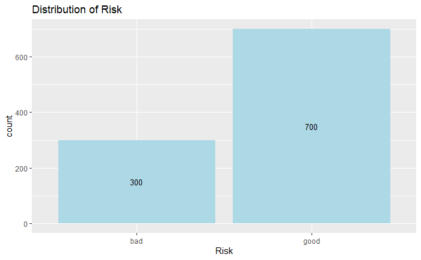

In the dataset, we can see that 70% of the observations are listed as “good” in terms of credit risk, while 30% are listed as “bad”. This baseline will help us as we compare the other distributions to the way that the `Risk` class is distributed.

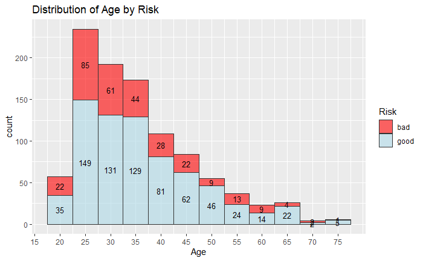

Looking at the `Age` distribution, we can see a couple of interesting insights. First, we see that generally the younger you are, the more likely you will be a “bad” credit risk. In the `Age` 25-30 bin, we see that the ratio is about `85/234` “bad” risks, or about 36%. Compare that to the overall `Risk` distribution of “bad” risks being at 30% “bad”.

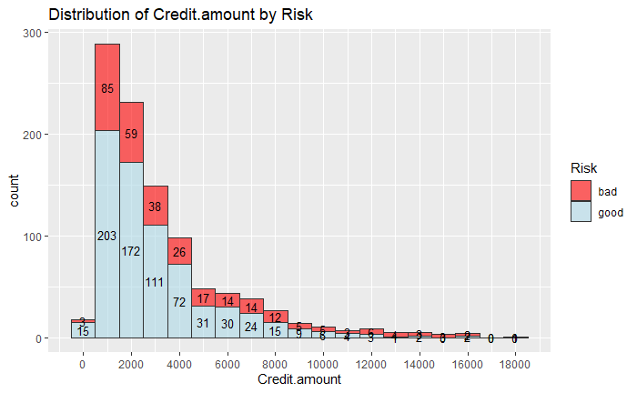

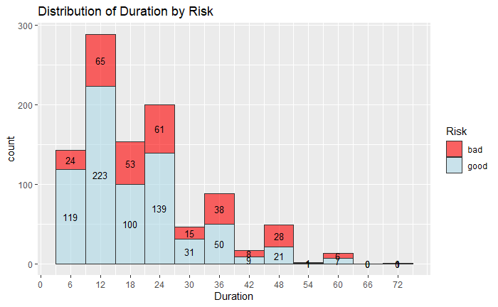

The `Duration` column shows that the shorter the duration of credit, the higher chance of being a “good” credit risk. As the duration increases, the ratio of good to bad credit risk decreases, as well.

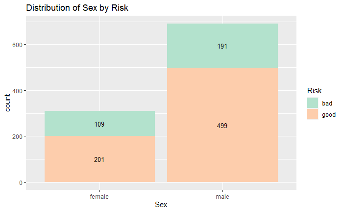

When looking at the distribution of `Sex`, we see that for females, about 65% are labeled as a “good” credit risk. This is lower than the 70% baseline number, meaning that there is some implicit bias in this data. For males, that ratio is at 72%, which is higher than the 70% baseline. Including this feature will add bias to a predictive model and should not be included in the list of features.

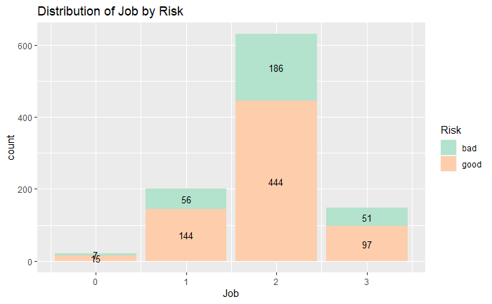

Interestingly, it seems that the `Job` distribution has some mixed results. Observations with job class 0 or 3 are under the 70% “good” credit risk ratio, while the other two classes are above the 70% ratio.

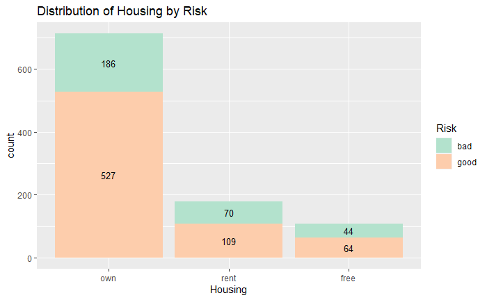

Those observations who are renting have a “good” credit risk ratio of 61%, well below the 70% baseline. Those who are “free” have an even lower ratio of 59%.

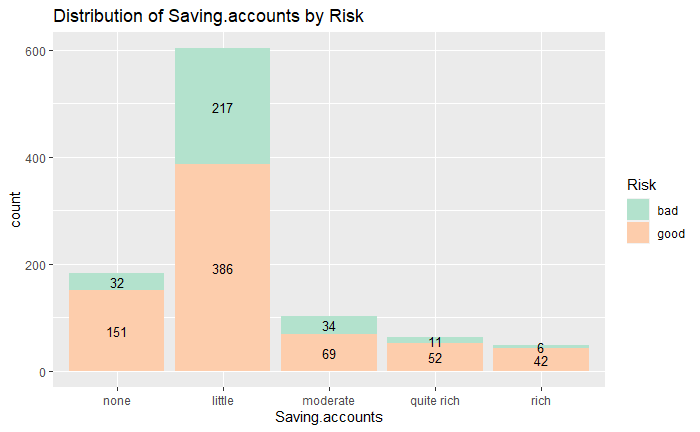

Interesting, values of “none” for `Saving.accounts` has a “good” risk ratio of 83%. Those that have “little” in the savings accounts had a ratio of 64%, which is below the 70% ratio. Those that had “moderate” amount of savings had a ratio of 67%.

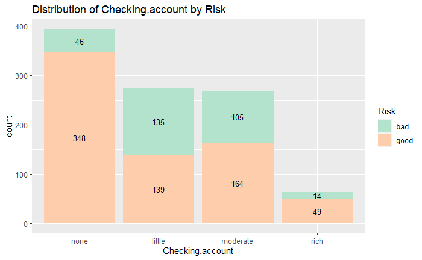

Values of “none” have a ratio of 88%. Interestingly, the values of “little” have a ratio of 51% and the values of “moderate” have a ratio of 61%. This feature will possibly be instrumental in predicting `Risk`.

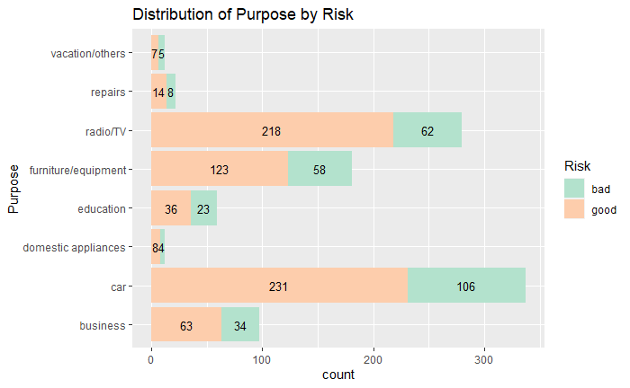

In the `Purpose` distribution, most of the classes are under the 70% “good” credit risk ratio, though nothing seems to be great significance.

## Visualizing each of the features with respect to credit$Sex

These next visualizations show the distributions of the features as grouped by `Sex`. However, as `Risk` is the target variable, these visualizations are more for reference and not as a critical analysis into next steps.

[figure not shown]

[figure not shown]

[figure not shown]

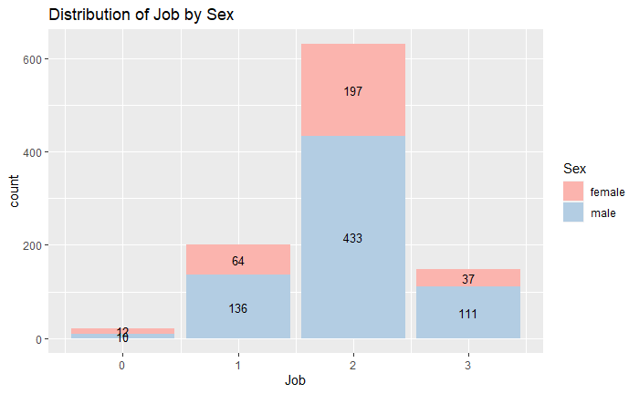

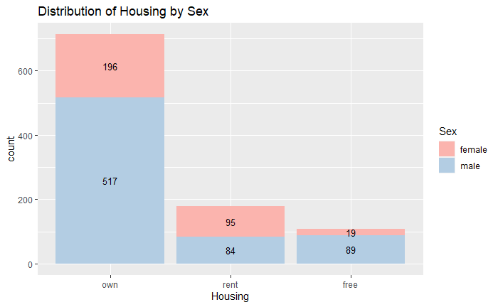

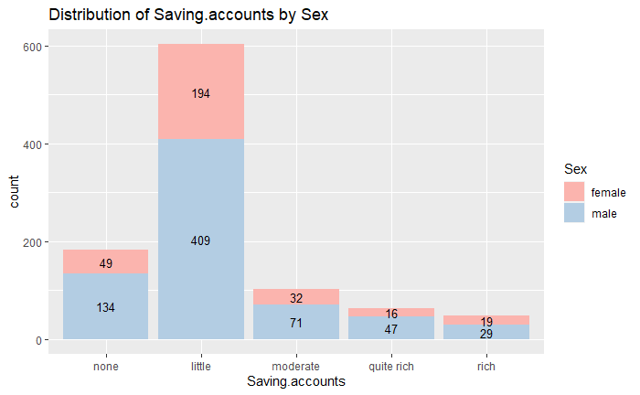

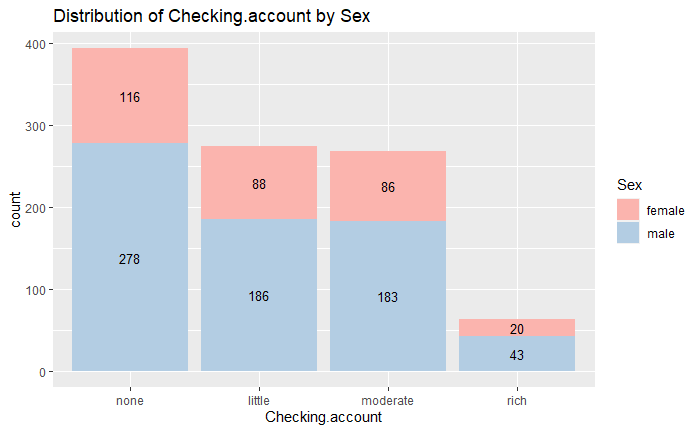

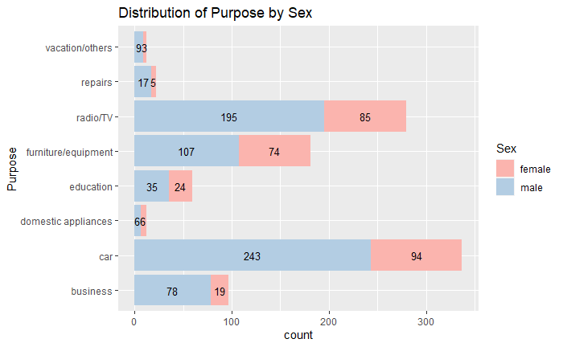

# Next Steps

As a result of the EDA, we can see that most of the features have predictive ability in predicting the target variable, `Risk`. However, a few suggestions going forward:

1. Including `Sex` in any model will introduce some bias. It is strongly suggested to leave `Sex` out of the features to include in modeling.
2. Doing a correlation analysis would be a crucial next step before modeling to see which features have strong predictive abbility. This is to be included in a later notebook.